# Analyse du risque de récidive du syndrome oculo-respiratoire après la vaccination contre la grippe. »

Saa Moussa TENGUIANO, Michelle Tchagang NGOUKEU, Biostatistique, Université Laval

**Résumé:** Ce rapport présente une analyse approfondie du risque de récidive du syndrome ocul-orespiratoire après la vaccination antigrippale. L’objectif est de comparer le risque de récidive entre les différents vaccins et le placebo, et de déterminer si ce risque varie selon le type de vaccin. Pour ce faire, une étude descriptive ainsi qu’une étude analytique utilisant un modèle GEE ont été réalisées afin d’estimer le risque de récidive du syndrome oculo-respiratoire après vaccination.

# 1 *Introduction.*

## 1.1 Contexte.

Le syndrome oculo-respiratoire (SOR) est un effet secondaire généralement bénin de la vaccination antigrippale, se manifestant par une rougeur des yeux, un mal de gorge, de la toux, des difficultés respiratoires ou un œdème facial. Ces symptômes apparaissent le plus souvent entre 2 et 12 heures après la vaccination, mais certains cas surviennent dès quelques minutes ou jusqu’à 48 à 72 heures après l’injection (INSPQ, 2001).

Le SOR a été identifié pour la première fois au Québec lors de la campagne de vaccination contre l’influenza 2000-2001, ce qui a soulevé des inquiétudes quant à la sécurité des vaccins. La majorité des cas étaient associés au vaccin Fluviral S/F, tandis qu’une minorité concernait d’autres vaccins comme Vaxigrip et Fluzone. Pour réduire le risque, Fluviral S/F a été modifié lors de la campagne 2001-2002, ce qui a entraîné une diminution significative du nombre de cas et une atténuation des symptômes, bien que le SOR n’ait pas complètement disparu (INSPQ, 2001).

La question de la récidive chez les personnes ayant déjà présenté un SOR a été étudiée par Skowronski et al. (2003) dans le cadre d’un essai clinique randomisé et contrôlé par placebo, qui a été interrompu lorsque le risque attribuable au vaccin est devenu trop élevé. En parallèle, une enquête téléphonique menée par Skowronski et al. (2002) a montré que le risque de récidive après revaccination était estimé à 5 % (IC à 95 % : 2,2 %-10,5 %).

Dans ce contexte, l’objectif de l’étude était d’évaluer le risque de récidive du SOR chez les personnes affectées en 2000-2001, pour chacun des vaccins disponibles au Canada lors de la saison grippale 2002-2003, afin d’éclairer la pratique de la revaccination et les recommandations de santé publique.

Ainsi, cette étude illustre de manière concrète plusieurs concepts clés abordés dans le cours sur les essais cliniques et les interventions, notamment le choix du devis expérimental (essai clinique randomisé en double aveugle avec placebo,plan croisé), la définition de la population cible, la mise en place de l’intervention, la distinction entre issues principales et secondaires, ainsi que l’analyse et l’interprétation des résultats.

## 1.2 Conception de l’étude

L’étude était un essai clinique contrôlé à plan croisé, mené dans trois sites au Canada (Vancouver, Québec, Montérégie). Trois groupes de patients agés de 18 ans ayant déjà présenté un SOR ont été constitués selon leur historique vaccinal antérieur. Les patients déjà vaccinés, indisponibles pour le suivi ou présentant des conditions pouvant masquer des symptômes du SOR étaient exclus. Chaque participant recevait deux injections à 7 jours d’intervalle : une dose de vaccin (Fluviral S/F ou Vaxigrip) et un placebo, selon une séquence randomisée en blocs de 4. La randomisation était effectuée séparément par site et par groupe. L’aveuglement était maintenu grâce à des seringues opaques préparées par une infirmière indépendante. Le placebo était une solution saline isotonique. Les vaccins utilisés provenaient d’un seul lot chacun et contenaient des souches grippales standardisées, avec différents agents de fragmentation selon le produit. La collecte des données comprenait un carnet de suivi quotidien des symptômes (jours 1 à 7), des appels téléphoniques au jour 1 (pour les symptômes initiaux) et au jour 3 si symptômes, ainsi qu’une visite de suivi environ une semaine plus tard lors de la seconde injection. Le SOR était défini selon la définition nationale de 2001 : apparition dans les 24 h post-vaccination d’au moins un symptôme typique (rougeur oculaire bilatérale, toux, dyspnée, œdème facial, etc.). Des définitions plus strictes étaient explorées en analyses secondaires. La sévérité était classée en trois niveaux selon l’impact sur les activités quotidiennes.

## 1.3 Objectifs et plan d’analyse.

L’objectif principal de ce rapport est d’évaluer le risque de récidive du SOR après une vaccination antigrippale. Plus précisément, il s’agit : de comparer le risque de récidive du SOR entre les vaccins et le placebo, et de comparer les risques de récidive entre les différents vaccins. Pour atteindre ces objectifs, l’analyse sera structurée de la manière suivante : une analyse descriptive du risque de récidive, et une modélisation statisque pour tenir compte des facteurs pertinents.

# 2 *Analyse du risque de récidive du syndrome oculo-respiratoire après la vaccination contre la grippe.*

Pour analyser le risque de récidive du SOR, nous commencerons par décrire la base de données issue de l’étude et créer des variables supplémentaires nécessaires à l’analyse.

## 2.1 Description de la base de données

| AGE | SEXE | CATEGORIE | id | region | traitement | dose | SOR:>=1 symptôme:24h |
| --- | --- | --- | --- | --- | --- | --- | --- |
| 64 | 1 | B | 100 | M | Placebo-Fluviral | 1 | 2 |
| 64 | 1 | B | 100 | M | Placebo-Fluviral | 2 | 2 |
| 46 | 1 | B | 101 | M | Placebo-Vaxigrip | 1 | 2 |

La base de données comprend **292 observations** pour 146 participants réparties sur **8 variables principales**:

- **age** : âge du participant au moment de l’inclusion.
- **catégorie** : variable factorielle à trois modalités (A, B et C) définissant le groupe d’appartenance des participants.
  - **Groupe A** : participants ayant présenté un SOR en 2000-2001 et **non revaccinés** contre la grippe.
  - **Groupe B** : participants ayant présenté un SOR en 2000-2001 et **revaccinés** en 2001-2002.
  - **Groupe C** : participants présentant une **première occurrence** de SOR en 2001-2002.
- **SOR** : indicateur de la présence d’au moins un symptôme de SOR survenant dans les **24 heures** suivant la vaccination.
- **dose** : ordre des interventions, correspondant à la **première ou la deuxième injection**.
- **identifiant** : identifiant unique attribué à chaque participant, chacun ayant **deux observations** correspondant aux deux doses reçues.
- **région** : région de recrutement des participants (Vancouver, Québec ou Montérégie).
- **traitement** : intervention administrée à chaque visite, précisant **placebo ou vaccin**, ainsi que le type de vaccin utilisé.

Pour la suite de l’analyse, deux variables supplémentaires seront créées :

**Traitement reçu** : indiquant le traitement effectivement reçu par le participant en tenant compte de la dose. **SOR_bin** : variable binaire valant 1 si le participant présente au moins un symptôme de SOR et 0 sinon.

## 2.2 Création des variables

| AGE | SEXE | CATEGORIE | id | region | traitement | dose | SOR:>=1 symptôme:24h | traitement_recu | SOR_bin |
| --- | --- | --- | --- | --- | --- | --- | --- | --- | --- |
| 64 | 1 | B | 100 | M | Placebo-Fluviral | 1 | 2 | Placebo | 0 |
| 64 | 1 | B | 100 | M | Placebo-Fluviral | 2 | 2 | Fluviral | 0 |

La nouvelle base de données comporte désormais 10 variables. Pour l’analyse descriptive, nous retiendrons les variables suivantes : catégorie, région, traitement, traitement reçu et la variable SOR_bin.

## 2.3 Caractéristiques des 146 participants par groupe

Répartition des participants par région et groupe

| Région | A | B | C |
| --- | --- | --- | --- |
| M | 33 | 38 | 20 |
| Q | 17 | 34 | 68 |
| V | 50 | 28 | 12 |

La répartition géographique des participants varie selon le groupe SOR : le **groupe A** est majoritairement recruté à Vancouver et Montérégie, avec une faible représentation à Québec ; le **groupe B** est réparti de manière relativement équilibrée entre Montérégie et Québec, avec moins de participants à Vancouver ; enfin, le **groupe C** est principalement recruté à Québec, avec une présence beaucoup plus faible à Montérégie et Vancouver.

## 2.4 *Comparaison des risques de récidive du syndrome oculo-respiratoire entre les vaccins et le Placebo*

### 2.4.1 Comparaison des taux d’incidence du syndrome oculo-respiratoire entre le vaccin fluviral et le Placebo

#### 2.4.1.1 Calcul des proportions d’incidence

Le tableau ci-dessous présente le nombre de cas de syndrome oculo‑respiratoire chez les patients ayant reçu le placebo, comparé à ceux ayant reçu le Fluviral, ainsi que les proportions d’incidence correspondantes.

Résumé des cas : Placebo contre Fluviral

| Vaccin reçu | Nombre total | Nombre de cas | Incidence (%) |
| --- | --- | --- | --- |
| Fluviral | 73 | 31 | 42.5 |
| Placebo | 73 | 6 | 8.2 |

Le tableau montre que le risque de récidive du SOR est de 42.5 % chez les patients ayant reçu le vaccin Fluviral, contre 8.2 % chez ceux ayant reçu le placebo.

#### 2.4.1.2 Calcul de la différence d’incidence et l’intervalle de confiance

Le tableau ci‑dessous présente la différence des taux d’incidence entre le vaccin Fluviral et le placebo.

Différence d'incidence : Fluviral contre Placebo

| Vaccins | Différence d'incidence | Intervalle de confiance |
| --- | --- | --- |
| Fluviral contre Placebo | 34% | (IC à 95%: 21%-47%) |

La vaccination avec Fluviral augmente le risque de récidive du SOR de 34 % par rapport au placebo (IC 95 % : 21% ;47 %). Comme l’intervalle de confiance n’inclut pas la valeur nulle, cette différence est statistiquement significative.

### 2.4.2 Comparaison des taux d’incidence du syndrome oculo-respiratoire entre le vaccin Vaxigrip et le Placebo

#### 2.4.2.1 Calcul des proportions d’incidence

Le tableau ci-dessous présente le nombre de cas du SOR chez les patients ayant reçu le placebo, comparé à ceux ayant reçu le Vaxigrip, ainsi que les proportions d’incidence correspondantes.

Résumé des cas : Placebo contre Vaxigrip

| Vaccin reçu | Nombre total | Nombre de cas | Incidence (%) |
| --- | --- | --- | --- |
| Placebo | 73 | 10 | 13.7 |
| Vaxigrip | 73 | 21 | 28.8 |

Le tableau indique que le risque de récidive du syndrome oculo‑respiratoire est de 28.8 % chez les patients ayant reçu le vaccin Vaxigrip, contre 13.7 % chez ceux ayant reçu le placebo.

#### 2.4.2.2 Calcul de la différence d’incidence et l’intervalle de confiance

Le tableau suivant présente la différence des taux d’incidence entre le vaccin Vaxigrip et le placebo.

Différence d'incidence

| Vaccins | Différence d'incidence | Intervalle de confiance |
| --- | --- | --- |
| Vaxigrip vs Placebo | 15% | (IC à 95%: 2%;28%) |

La vaccination avec Vaxigrip augmente le risque de récidive du syndrome oculo‑respiratoire de 15 % par rapport au placebo (IC 95 % : 2 % à 28 %). Comme l’intervalle de confiance n’inclut pas zéro, cette différence est statistiquement significative.

### 2.4.3 Comparaison des taux d’incidence du syndrome oculo-respiratoire entre les vaccins fluviral et Vaxigrip

Différence d’incidence : Fluviral vs Vaxigrip

| Vaccins | Différence d'incidence | Intervalle de confiance |
| --- | --- | --- |
| Fluviral contre Vaxigrip | 13.7% | (IC à 95%: -1.7%;29.1%) |

La différence d’incidence du SOR entre Fluviral et Vaxigrip est de 13.7 % (IC 95 % : -1.7 % à 29.1 %). Comme l’intervalle de confiance inclut zéro, cette différence n’est pas statistiquement significative, indiquant qu’aucun vaccin n’a montré un avantage clair sur l’autre dans cette étude.

# 3 Modélisation statistique du risque de récidive du syndrome oculo-respiratoire

Afin d’analyser plus en profondeur la différence de risque de SOR entre les vaccins Fluviral, Vaxigrip et le placebo, nous utiliserons un modèle statistique adapté à la structure de nos données : le modèle GEE (Generalized Estimating Equations). Ce modèle est particulièrement approprié aux données longitudinales ou répétées, car il permet de tenir compte de la corrélation entre les mesures provenant du même participant, tout en estimant des effets moyens au niveau de la population. Pour cette analyse, nous avons retenu les variables suivantes : identifiant, catégorie,SOR_bin et traitement reçu : La variable identifiant permet d’indiquer que les mesures sont répétées sur le même participant, ce qui est essentiel pour modéliser la corrélation intra-sujet et obtenir des erreurs standard robustes. La variable catégorie (groupes A, B, C) permet d’examiner comment le risque du SOR varie entre les différents groupes de participants et de contrôler les différences structurelles entre eux. La variable SOR_bin constitue la variable réponse, indiquant la survenue ou non du SOR. Enfin, la variable traitement reçu correspond à l’exposition principale (vaccin ou placebo) dont nous souhaitons estimer l’effet sur le risque du SOR.

## 3.1 Choix du modèle GEE adapté

Le choix du modèle GEE approprié dépend essentiellement de la structure de corrélation entre les mesures répétées.Puisque les données présentent deux mesures répétées,nous allons dans le cadre de cette analyse examiner deux structures de corrélation : la structure indépendante et la structure exchangeable.En effet, lorsqu’il y a peu de mesures répétées, les structures de corrélation exchangeable et autorgressive donnent la même matrice de corrélation.

**Structure indépendante** : les mesures répétées sont supposées indépendantes les unes des autres.

**Structure échangeable (exchangeable)** : toutes les paires de mesures répétées d’un même sujet ont la même corrélation.

L’examen de ces différentes structures permettra de sélectionner le modèle GEE le plus approprié pour capturer la dépendance intra-sujet et produire des estimations fiables.Le critère de selection privilégié dans le cadre de notre analyse est le **QIC** ( Quasi Information Criterion).

Les résultats de comparaison présentés dans le tableau ci-dessous montrent que les modèles obtiennent des valeurs de QIC très proches. Puisque les mesures ne présentent pas de corrélation intra-individu notable, nous retenons pour l’analyse finale le modèle utilisant une structure de corrélation indépendante.

```
                           QIC     QICu Quasi Lik      CIC params     QICC
  Modele_independante 295.1886 295.2622 -142.6311 4.963167      5 295.6171
  Modele_exchangeable 295.2072 295.2640 -142.6320 4.971605      5 295.8115
```

## 3.2 Resultats du modèle choisi.

Rapport des côtes du modèle retenu

| Coefficient | Rapport des côtes | IC 95% (borne inféreure) | IC 95% (borne supérieure) |
| --- | --- | --- | --- |
| (Intercept) | 0.927 | 0.510 | 1.685 |
| CATEGORIEB | 0.561 | 0.270 | 1.166 |
| CATEGORIEC | 0.897 | 0.460 | 1.750 |
| traitement_recuPlacebo | 0.164 | 0.082 | 0.328 |
| traitement_recuVaxigrip | 0.544 | 0.273 | 1.085 |

Dans le modèle GEE retenu, la catégorie de référence était la catégorie A et le traitement de référence le Fluviral. Les patients des catégories B et C ne présentaient pas de différence statistiquement significative de la côte de développer le SOR par rapport à la catégorie A (OR = 0.561 et 0.897, respectivement, IC 95% incluant 1). Concernant le traitement reçu, l’administration du placebo comparé au Fluviral était associée à une réduction significative de la côte de développer le SOR (OR = 0.164, IC 95% : 0.082 ; 0.328), tandis que l’administration du Vaxigrip comparé au Fluviral entraînait une réduction non significative de la côte (OR = 0.544, IC 95% : 0.273 ;1.085).

## 3.3 Comparaison des vaccins avec le placebo en utilisant les différences de risque plutôt que les rapports de côtes.

```
                           Différence Ecart_type   Borne_inf  Borne_sup
  (Intercept)              0.11593305 0.03423912  0.04882436 0.18304173
  CATEGORIEB              -0.03627270 0.04934885 -0.13299645 0.06045104
  CATEGORIEC               0.02282346 0.05320116 -0.08145081 0.12709773
  traitement_recuFluviral  0.31272115 0.06225286  0.19070555 0.43473676
  traitement_recuVaxigrip  0.17623947 0.05852976  0.06152115 0.29095779
```

Le risque de SOR est significativement plus élevé chez les participants ayant reçu Fluviral comparé au placebo, avec une différence de 31.27 % (IC 95 % : 19.07 % à 43.47 %). Pour Vaxigrip, le risque a également augmenté par rapport au placebo, avec une différence de 17.62 % (IC 95 % : 6.15 % à 29.09 %).

## 3.4 Comparaison entre les vaccins en utilisant les différences de risque plutôt que les rapports de côtes.

```
                           Différence Ecart_type   Borne_inf   Borne_sup
  (Intercept)              0.29217252 0.06160698  0.17142285  0.41292219
  CATEGORIEB              -0.03627270 0.04934885 -0.13299645  0.06045104
  CATEGORIEC               0.02282346 0.05320116 -0.08145081  0.12709773
  traitement_recuPlacebo  -0.17623947 0.05852976 -0.29095779 -0.06152115
  traitement_recuFluviral  0.13648168 0.07814897 -0.01669030  0.28965366
```

La comparaison entre les deux vaccins montre une différence de risque de 13.65 % (IC 95 % : -1.67 % à 28.97 %). Puisque l’intervalle de confiance contient la valeur nulle, alors la différence de risque entre les deux vaccins n’est pas statistiquement significatif.

**Conclusion :** Les deux vaccins augmentent le risque de récidive du SOR par rapport au placebo. Cependant le risque entre les deux vaccins ne diffère pas.

# 4 *Conclusion Générale*

L’étude visait à évaluer le risque de récidive du syndrome oculo-respiratoire après vaccination et à comparer ce risque entre Fluviral, Vaxigrip et placebo. L’analyse descriptive a montré que le risque du SOR était plus élevé après Fluviral (42.5 %) qu’après Vaxigrip (28.8 %) ou placebo (8.2 %). Le modèle GEE a confirmé ces tendances : la différence de risque ajustée était de 31.27 % pour Fluviral contre placebo, 17.62 % pour Vaxigrip contre placebo.Aucun vaccin n’a montré un avantage sur l’autre dans cette étude (Voir annexe aussi)

# 5 *Références*

1-Skowronski, D. M., De Serres, G., Scheifele, D., Russell, M. L., Warrington, R., Davies, H. D., Dionne, M., Duval, B., Kellner, J., & MacDonald, J. (2003). Randomized, double-blind, placebo-controlled trial to assess recurrence risk of oculorespiratory syndrome following influenza vaccination in previously affected persons. Clinical Infectious Diseases, 37(8), 1059–1066. https://doi.org/10.1086/378274

2-Skowronski, D. M., Strauss, B., Kendall, P., Duval, B., & De Serres, G. (2002). Low risk of recurrence of oculorespiratory syndrome following influenza revaccination. CMAJ, 167(8), 853–858.

3-Groupe scientifique en immunisation, Institut national de santé publique du Québec. (2001, novembre). Syndrome oculo-respiratoire observé après la vaccination contre l’influenza. INSPQ. http://www.inspq.qc.ca

4-De Serres, G., Skowronski, D. M., Guay, M., Rochette, L., Jacobsen, K., Fuller, T., & Duval, B. (2003). Recurrence risk of oculorespiratory syndrome after influenza vaccination: Randomized controlled trial of previously affected persons. Clinical Infectious Diseases, 37(8), 1059–1066. https://doi.org/10.1086/378274

5-Diggle, P. J., Heagerty, P. J., Liang, K.-Y., & Zeger, S. L. (2002). Analysis of Longitudinal Data (2nd ed.). Oxford University Press.

6-https://search.r-project.org/CRAN/refmans/geepack/html/QIC.html

# 6 Annexe

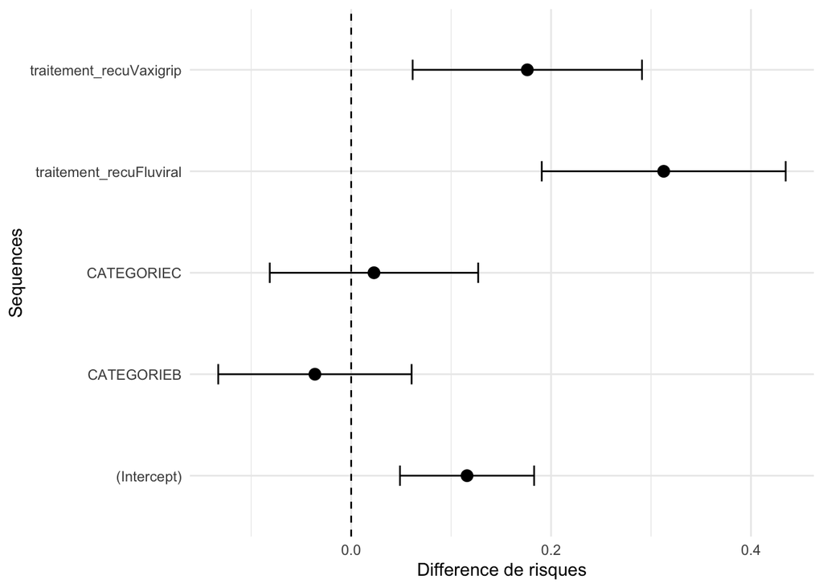